# Olympic Games Analysis

- Introduction
- Questions
- Data Preparation & Exploration
- Athlete Participation in the Olympic Games
- Top Medaling Countries in the Olympic Games
- Top Female Gold Medalists
- Top Male Gold Medalists
- Average Height, Weight, & Age of Female Athletes by Sport
- Average Height, Weight, & Age of Male Athletes by Sport

## Introduction

As someone who loves sports and data, nothing speaks to a perfect marriage of my two passions than looking into data on the Olympics. The motivation behind this project was to use data to answer a series of questions surrounding the Olympic games from 1896 to 2016.

## Questions

1. What is the athlete participation rate at the Olympic Games in the past 120 years?
   - How did the athlete participation rate differ from Summer and Winter games?
2. What countries came up on top in the Olympic Games?
   - Which countries had the most gold medals?
   - Which countries had the most silver medals?
   - Which countries had the most bronze medals?
3. Who are the top female and male athletes of all time?
4. What were the average height, weight, and age of female athletes by sport (from 1960 to 2016)?
5. What were the average height, weight, and age of male athletes by sport (from 1960 to 2016)?

## Data Preparation & Exploration

```python
# Load Packages

import pandas as pd
import numpy as np
import seaborn as sns
import matplotlib.pyplot as plt

%matplotlib inline

from bokeh.plotting import output_notebook, output_file, figure, show
from bokeh.palettes import Plasma256, Cividis256
from bokeh.transform import factor_cmap
from bokeh.models import ColumnDataSource
from bokeh.models.tools import HoverTool
output_notebook()
```

```python
# Load Olympic CSV file

olympic_data = pd.read_csv('Data/athlete_events_edt.csv')
olympic_data.shape
```

```
(269383, 15)
```

```python
# Load NOC CSV file

noc_data = pd.read_csv('Data/noc_regions.csv')
noc_data.shape
```

```
(231, 3)
```

```python
# Preview Olympic dataset

olympic_data.head()
```

|  | ID | Name | Sex | Age | Height | Weight | Team | NOC | Games | Year | Season | City | Sport | Event | Medal |
| --- | --- | --- | --- | --- | --- | --- | --- | --- | --- | --- | --- | --- | --- | --- | --- |
| 0 | 1 | A Dijiang | M | 24.0 | 180.0 | 80.0 | China | CHN | 1992 Summer | 1992 | Summer | Barcelona | Basketball | Basketball Men's Basketball | NaN |
| 1 | 2 | A Lamusi | M | 23.0 | 170.0 | 60.0 | China | CHN | 2012 Summer | 2012 | Summer | London | Judo | Judo Men's Extra-Lightweight | NaN |
| 2 | 3 | Gunnar Nielsen Aaby | M | 24.0 | NaN | NaN | Denmark | DEN | 1920 Summer | 1920 | Summer | Antwerpen | Football | Football Men's Football | NaN |
| 3 | 4 | Edgar Lindenau Aabye | M | 34.0 | NaN | NaN | Denmark/Sweden | DEN | 1900 Summer | 1900 | Summer | Paris | Tug-Of-War | Tug-Of-War Men's Tug-Of-War | Gold |
| 4 | 5 | Christine Jacoba Aaftink | F | 21.0 | 185.0 | 82.0 | Netherlands | NED | 1988 Winter | 1988 | Winter | Calgary | Speed Skating | Speed Skating Women's 500 metres | NaN |

```python
# Preview NOC dataset

noc_data.head()
```

|  | NOC | Region | Notes |
| --- | --- | --- | --- |
| 0 | AFG | Afghanistan | NaN |
| 1 | AHO | Curacao | Netherlands Antilles |
| 2 | ALB | Albania | NaN |
| 3 | ALG | Algeria | NaN |
| 4 | AND | Andorra | NaN |

```python
# Merge Olympic dataset with NOC dataset to by 'NOC' Country and rename Region --> Country

olympic_metadata = pd.merge(olympic_data, noc_data, on = 'NOC', how = 'left')
olympic_metadata = olympic_metadata.rename(columns = {'Region':'Country'})
olympic_metadata.head()
```

|  | ID | Name | Sex | Age | Height | Weight | Team | NOC | Games | Year | Season | City | Sport | Event | Medal | Country | Notes |
| --- | --- | --- | --- | --- | --- | --- | --- | --- | --- | --- | --- | --- | --- | --- | --- | --- | --- |
| 0 | 1 | A Dijiang | M | 24.0 | 180.0 | 80.0 | China | CHN | 1992 Summer | 1992 | Summer | Barcelona | Basketball | Basketball Men's Basketball | NaN | China | NaN |
| 1 | 2 | A Lamusi | M | 23.0 | 170.0 | 60.0 | China | CHN | 2012 Summer | 2012 | Summer | London | Judo | Judo Men's Extra-Lightweight | NaN | China | NaN |
| 2 | 3 | Gunnar Nielsen Aaby | M | 24.0 | NaN | NaN | Denmark | DEN | 1920 Summer | 1920 | Summer | Antwerpen | Football | Football Men's Football | NaN | Denmark | NaN |
| 3 | 4 | Edgar Lindenau Aabye | M | 34.0 | NaN | NaN | Denmark/Sweden | DEN | 1900 Summer | 1900 | Summer | Paris | Tug-Of-War | Tug-Of-War Men's Tug-Of-War | Gold | Denmark | NaN |
| 4 | 5 | Christine Jacoba Aaftink | F | 21.0 | 185.0 | 82.0 | Netherlands | NED | 1988 Winter | 1988 | Winter | Calgary | Speed Skating | Speed Skating Women's 500 metres | NaN | Netherlands | NaN |

```python
# Inspect Olympic dataset

olympic_metadata.info()
```

```
<class 'pandas.core.frame.DataFrame'>
Int64Index: 269383 entries, 0 to 269382
Data columns (total 17 columns):
ID         269383 non-null int64
Name       269383 non-null object
Sex        269383 non-null object
Age        260652 non-null float64
Height     210688 non-null float64
Weight     208036 non-null float64
Team       269383 non-null object
NOC        269383 non-null object
Games      269383 non-null object
Year       269383 non-null int64
Season     269383 non-null object
City       269383 non-null object
Sport      269383 non-null object
Event      269383 non-null object
Medal      39325 non-null object
Country    269383 non-null object
Notes      4277 non-null object
dtypes: float64(3), int64(2), object(12)
memory usage: 37.0+ MB
```

```python
olympic_metadata.describe()
```

|  | ID | Age | Height | Weight | Year |
| --- | --- | --- | --- | --- | --- |
| count | 269383.000000 | 260652.000000 | 210688.000000 | 208036.000000 | 269383.000000 |
| mean | 68233.209089 | 25.550941 | 175.335472 | 70.697254 | 1978.844107 |
| std | 39023.499143 | 6.386385 | 10.521335 | 14.349271 | 29.402336 |
| min | 1.000000 | 10.000000 | 127.000000 | 25.000000 | 1896.000000 |
| 25% | 34639.500000 | 21.000000 | 168.000000 | 60.000000 | 1960.000000 |
| 50% | 68177.000000 | 24.000000 | 175.000000 | 70.000000 | 1988.000000 |
| 75% | 102086.500000 | 28.000000 | 183.000000 | 79.000000 | 2002.000000 |
| max | 135571.000000 | 97.000000 | 226.000000 | 214.000000 | 2016.000000 |

```python
# Inspect missing data

olympic_metadata.isnull().sum()
```

```
ID              0
Name            0
Sex             0
Age          8731
Height      58695
Weight      61347
Team            0
NOC             0
Games           0
Year            0
Season          0
City            0
Sport           0
Event           0
Medal      230058
Country         0
Notes      265106
dtype: int64
```

Missing data occurs in the "Age", "Height", "Weight", "Medal", and "Notes" columns.

- "Medal" column has a lot of NaN because not every athlete medaled.
- "Notes" column has names of countries that are 'formerly known as' and therefore has a lot of NaN.

## Athlete Participation in the Olympic Games

```python
# Create new dataframe to analyze athlete participation in Olympics.
# Using value counts on 'ID' to avoid counting same althletes

athl_count = olympic_metadata.groupby(['Games', 'City'])['ID'].value_counts()
athl_count = athl_count.groupby(['Games']).count().reset_index()
athl_count = athl_count.rename(columns = {'ID': 'Athlete Count'})
athl_count.head()
```

|  | Games | Athlete Count |
| --- | --- | --- |
| 0 | 1896 Summer | 176 |
| 1 | 1900 Summer | 1224 |
| 2 | 1904 Summer | 650 |
| 3 | 1908 Summer | 2024 |
| 4 | 1912 Summer | 2409 |

```python
# Split Games Column into two columns (Year and Season)

yr_ssn = pd.DataFrame(athl_count.Games.str.split(' ', 1).tolist(), columns = ['Year', 'Season'])
yr_ssn.head()
```

|  | Year | Season |
| --- | --- | --- |
| 0 | 1896 | Summer |
| 1 | 1900 | Summer |
| 2 | 1904 | Summer |
| 3 | 1908 | Summer |
| 4 | 1912 | Summer |

```python
# Merge the two Dataframes(concatenation) and drop 'Games' column
# Also need to change 'Year' column from str to int

olympic_athl = pd.concat([yr_ssn, athl_count], axis = 1)
olympic_athl = olympic_athl.drop(columns = 'Games')
olympic_athl['Year'] = pd.to_numeric(olympic_athl['Year'])
olympic_athl.head()
```

|  | Year | Season | Athlete Count |
| --- | --- | --- | --- |
| 0 | 1896 | Summer | 176 |
| 1 | 1900 | Summer | 1224 |
| 2 | 1904 | Summer | 650 |
| 3 | 1908 | Summer | 2024 |
| 4 | 1912 | Summer | 2409 |

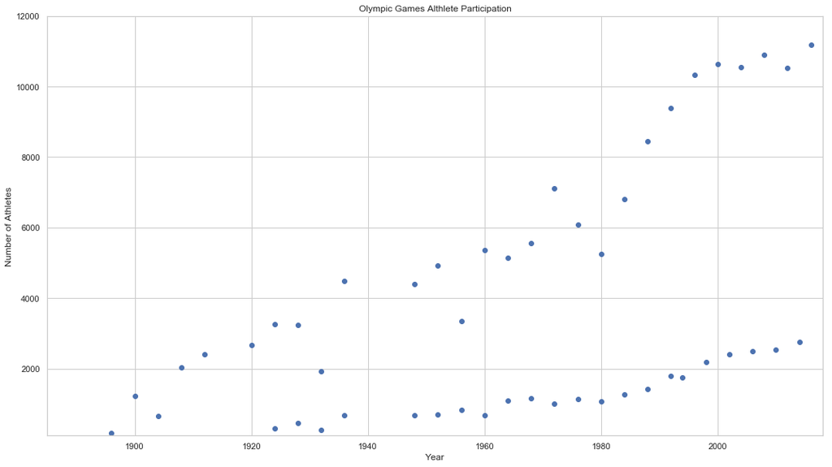

```python
# Create scatterplot to analyze overall athlete participation in Olympic games

# Set seaborn style and figure size)
sns.set(style = 'whitegrid')
plt.figure(figsize = (18, 10))

# Give chart title, labels, and limits
plt.title('Olympic Games Althlete Participation')
plt.xlabel('Year')
plt.xlim(1885, 2018)
plt.ylabel('Number of Athletes')
plt.ylim(100, 12000)
plt.scatter(x = olympic_athl['Year'], y = olympic_athl['Athlete Count'])
plt.savefig('Visualization/Olympic Athlete Participation.png')
```

```python
# Create a new dataframe for Summer games

summer_games = olympic_athl.loc[olympic_athl['Season'] == 'Summer'].reset_index(drop = True)
summer_games.shape
```

```
(28, 3)
```

```python
summer_games.head()
```

|  | Year | Season | Athlete Count |
| --- | --- | --- | --- |
| 0 | 1896 | Summer | 176 |
| 1 | 1900 | Summer | 1224 |
| 2 | 1904 | Summer | 650 |
| 3 | 1908 | Summer | 2024 |
| 4 | 1912 | Summer | 2409 |

```python
# Create new dataframe for Winter games

winter_games = olympic_athl.loc[olympic_athl['Season'] == 'Winter'].reset_index(drop = True)
winter_games.shape
```

```
(22, 3)
```

```python
winter_games.head()
```

|  | Year | Season | Athlete Count |
| --- | --- | --- | --- |
| 0 | 1924 | Winter | 313 |
| 1 | 1928 | Winter | 461 |
| 2 | 1932 | Winter | 252 |
| 3 | 1936 | Winter | 668 |
| 4 | 1948 | Winter | 668 |

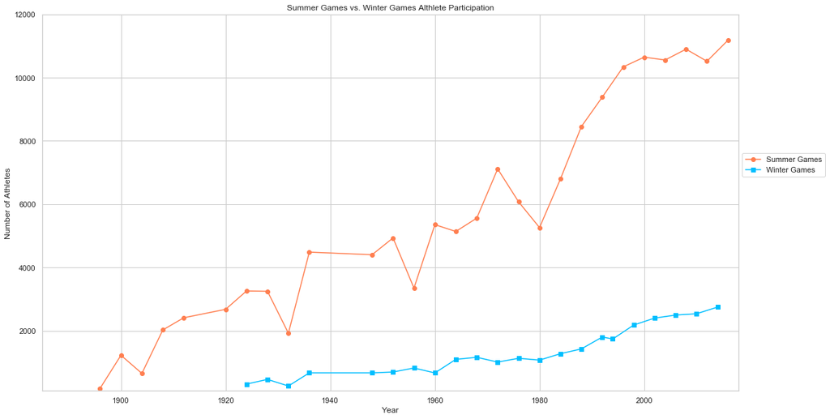

```python
# Create multi-line graph to compare athlete participation in both games

# Set seaborn style and figure size)
sns.set(style = 'whitegrid')
plt.figure(figsize = (18, 10))

# Give chart title, labels, and limits
plt.title('Summer Games vs. Winter Games Althlete Participation')
plt.xlabel('Year')
plt.xlim(1885, 2018)
plt.ylabel('Number of Athletes')
plt.ylim(100, 12000)

# Create handles for legend and plot multi-line graph
Summer, = plt.plot(summer_games['Year'], summer_games['Athlete Count'],
                  marker = 'o', color = 'coral', label = 'Summer Games')
Winter, = plt.plot(winter_games['Year'], winter_games['Athlete Count'],
                  marker = 's', color = 'deepskyblue', label = 'Winter Games')
plt.legend(handles = [Summer, Winter], loc = 'center left', bbox_to_anchor = (1, 0.6))
plt.savefig('Visualization/Summer Games vs Winter Games.png')
plt.show()
```

## Top Medaling Countries in the Olympic Games

```python
# Drop athletes that did not medal

medal_df = olympic_metadata.dropna(subset = ['Medal'])
medal_df.shape
```

```
(39325, 17)
```

```python
# Create Dataframe with Country Medal Count

country_medal_ct = medal_df.groupby(['Country'])['Medal'].count().reset_index(name = 'Medal Count')
country_medal_ct.head()
```

|  | Country | Medal Count |
| --- | --- | --- |
| 0 | Afghanistan | 2 |
| 1 | Algeria | 17 |
| 2 | Argentina | 274 |
| 3 | Armenia | 16 |
| 4 | Australia | 1346 |

```python
# Create Dataframe with top ten countries in medal count

top_ten_countries = country_medal_ct.sort_values('Medal Count', ascending = False).head(10).reset_index(drop = True)
top_ten_countries
```

|  | Country | Medal Count |
| --- | --- | --- |
| 0 | USA | 5613 |
| 1 | Russia | 3947 |
| 2 | Germany | 3726 |
| 3 | UK | 2029 |
| 4 | France | 1713 |
| 5 | Italy | 1581 |
| 6 | Sweden | 1515 |
| 7 | Canada | 1350 |
| 8 | Australia | 1346 |
| 9 | Hungary | 1122 |

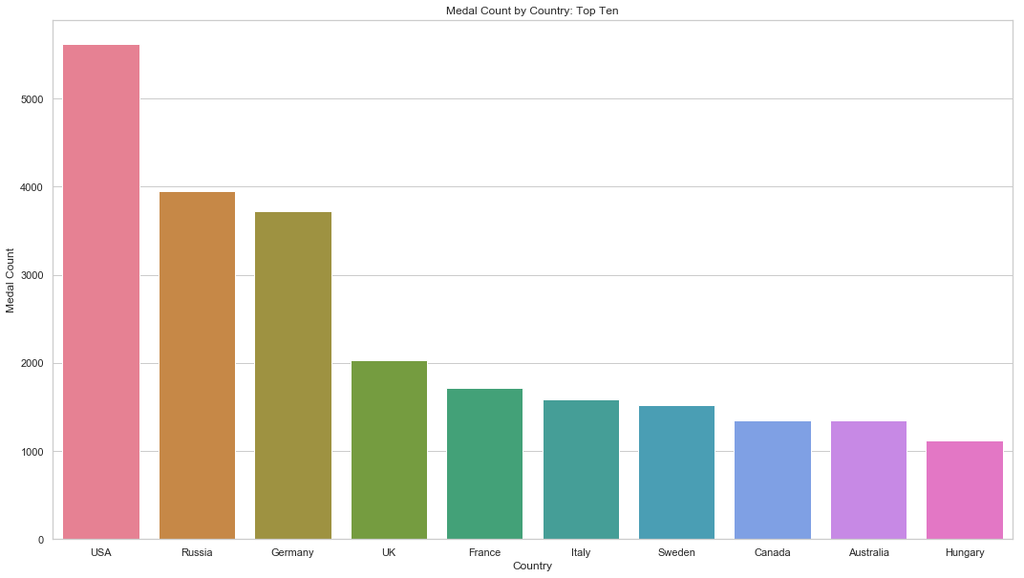

```python
# Set seaborn style and figure size)
sns.set(style = 'whitegrid')
plt.figure(figsize = (18, 10))

# Give chart title, labels, and limits
plt.title('Medal Count by Country: Top Ten')
plt.xlabel('Country')
plt.ylabel('Number of Medals Won')

# Plot barplot
sns.barplot(x = top_ten_countries['Country'],
            y = top_ten_countries['Medal Count'],
            palette = 'husl')

plt.savefig('Visualization/Top Ten Countries.png')
```

```python
# Create a Dataframe with Country, type of medal won, and medal count

medal_ct = medal_df.groupby(['Country'])['Medal'].value_counts().reset_index(name = 'Medal Count')
medal_ct.head()
```

|  | Country | Medal | Medal Count |
| --- | --- | --- | --- |
| 0 | Afghanistan | Bronze | 2 |
| 1 | Algeria | Bronze | 8 |
| 2 | Algeria | Gold | 5 |
| 3 | Algeria | Silver | 4 |
| 4 | Argentina | Silver | 92 |

```python
# Create a Dataframe with the top five countries who won the most gold medals

gold = medal_ct.loc[medal_ct['Medal'] == 'Gold'].reset_index(drop = True)
top_five_gold = gold.sort_values('Medal Count', ascending = False).head(5).reset_index(drop = True)
top_five_gold
```

|  | Country | Medal | Medal Count |
| --- | --- | --- | --- |
| 0 | USA | Gold | 2626 |
| 1 | Russia | Gold | 1599 |
| 2 | Germany | Gold | 1287 |
| 3 | UK | Gold | 669 |
| 4 | Italy | Gold | 554 |

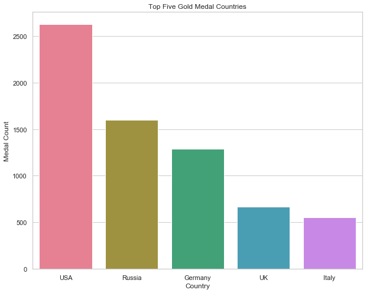

```python
# Set seaborn style and figure size)
sns.set(style = 'whitegrid')
plt.figure(figsize = (10, 8))

# Give chart title, labels, and limits
plt.title('Top Five Gold Medal Countries')
plt.xlabel('Country')
plt.ylabel('Number of Gold Medals Won')

# Plot barplot
sns.barplot(x = top_five_gold['Country'],
            y = top_five_gold['Medal Count'],
            palette = 'husl')

plt.savefig('Visualization/Top Five Gold.png')
```

```python
# Create a Dataframe with the top five countries who won the most silver medals

silver = medal_ct.loc[medal_ct['Medal'] == 'Silver'].reset_index(drop = True)
top_five_silver = silver.sort_values('Medal Count', ascending = False).head(5).reset_index(drop = True)
top_five_silver
```

|  | Country | Medal | Medal Count |
| --- | --- | --- | --- |
| 0 | USA | Silver | 1635 |
| 1 | Germany | Silver | 1185 |
| 2 | Russia | Silver | 1170 |
| 3 | UK | Silver | 717 |
| 4 | France | Silver | 594 |

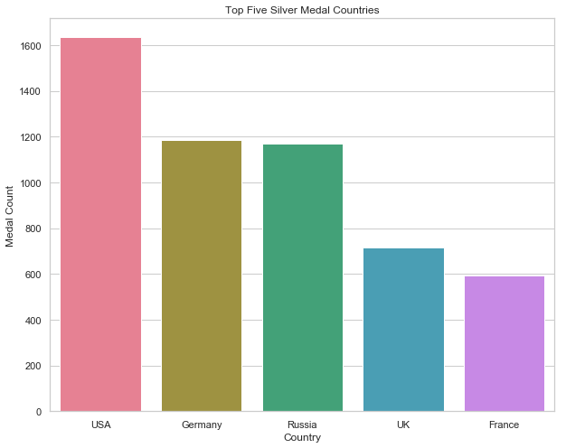

```python
# Set seaborn style and figure size)
sns.set(style = 'whitegrid')
plt.figure(figsize = (10, 8))

# Give chart title, labels, and limits
plt.title('Top Five Silver Medal Countries')
plt.xlabel('Country')
plt.ylabel('Number of Silver Medals Won')

# Plot barplot
sns.barplot(x = top_five_silver['Country'],
            y = top_five_silver['Medal Count'],
            palette = 'husl')

plt.savefig('Visualization/Top Five Silver.png')
```

```python
# Create a Dataframe with the top five countries who won the most bronze medals

bronze = medal_ct.loc[medal_ct['Medal'] == 'Bronze'].reset_index(drop = True)
top_five_bronze = bronze.sort_values('Medal Count', ascending = False).head(5).reset_index(drop = True)
top_five_bronze
```

|  | Country | Medal | Medal Count |
| --- | --- | --- | --- |
| 0 | USA | Bronze | 1352 |
| 1 | Germany | Bronze | 1254 |
| 2 | Russia | Bronze | 1178 |
| 3 | UK | Bronze | 643 |
| 4 | France | Bronze | 638 |

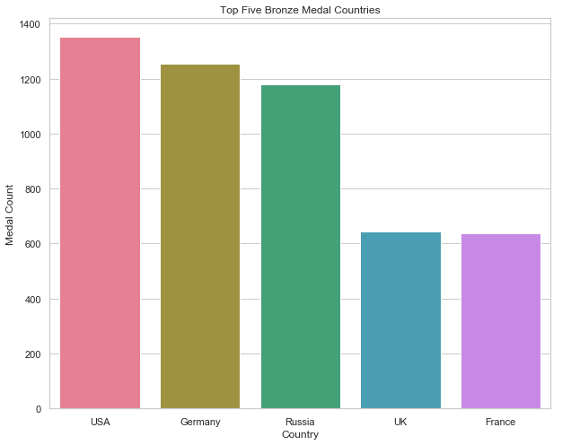

```python
# Set seaborn style and figure size)
sns.set(style = 'whitegrid')
plt.figure(figsize = (10, 8))

# Give chart title, labels, and limits
plt.title('Top Five Bronze Medal Countries')
plt.xlabel('Country')
plt.ylabel('Number of Bronze Medals Won')

# Plot barplot
sns.barplot(x = top_five_bronze['Country'],
            y = top_five_bronze['Medal Count'],
            palette = 'husl')

plt.savefig('Visualization/Top Five Bronze.png')
```

```python
# Create a Dataframe with gold medalist athletes

gold_athletes = medal_df.groupby(['Name', 'Sex', 'Sport'])['Medal'].count().reset_index(name = 'Golds Won')
gold_athletes.head()
```

|  | Name | Sex | Sport | Golds Won |
| --- | --- | --- | --- | --- |
| 0 | A. Albert | M | Rugby | 1 |
| 1 | A. Dubois | M | Sailing | 2 |
| 2 | A. Joshua "Josh" West | M | Rowing | 1 |
| 3 | A. Lawry | M | Rugby | 1 |
| 4 | A. M. Woods | M | Lacrosse | 1 |

```python
# Create Dataframe with top female gold medalists

female_gold = gold_athletes[gold_athletes['Sex'] == 'F']
female_gold = female_gold.sort_values('Golds Won', ascending = False).head(5).reset_index(drop = True)
female_gold
```

|  | Name | Sex | Sport | Golds Won |
| --- | --- | --- | --- | --- |
| 0 | Larysa Semenivna Latynina (Diriy-) | F | Gymnastics | 18 |
| 1 | Natalie Anne Coughlin (-Hall) | F | Swimming | 12 |
| 2 | Dara Grace Torres (-Hoffman, -Minas) | F | Swimming | 12 |
| 3 | Jennifer Elisabeth "Jenny" Thompson (-Cumpelik) | F | Swimming | 12 |
| 4 | Birgit Fischer-Schmidt | F | Canoeing | 12 |

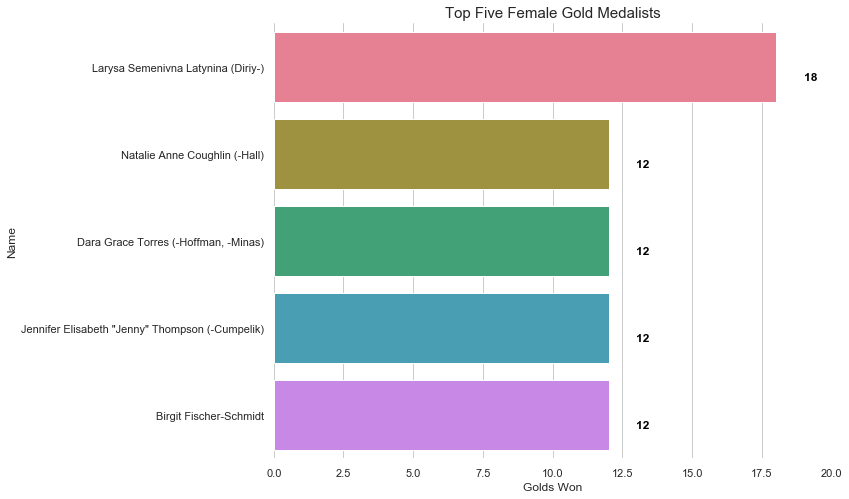

```python
# Set seaborn style and figure size)
sns.set(style = 'whitegrid')
plt.figure(figsize = (10, 8))

# Give chart title, labels, and limits
plt.title('Top Five Female Gold Medalists', fontsize = 15)
plt.xlabel('Number of Gold Medals Won')
plt.xlim(0, 20)
plt.ylabel('Name of Athlete')


# Plot barplot
sns.barplot(x = female_gold['Golds Won'], y = female_gold['Name'],
           palette = 'husl')

# Text of number of medals (at end of each bar)
for i, v in enumerate(female_gold['Golds Won']):
    plt.text(v + 1, i + .15, str(v), color = 'black', fontweight = 'bold', fontsize = 12)

# Removing axes spines
sns.despine(left = True, bottom = True)

plt.savefig('Visualization/Top Female Gold Medalists.png')
```

```python
# Create Dataframe with top male gold medalists
male_gold = gold_athletes[gold_athletes['Sex'] == 'M']
male_gold = male_gold.sort_values('Golds Won', ascending = False).head(5).reset_index(drop = True)
male_gold
```

|  | Name | Sex | Sport | Golds Won |
| --- | --- | --- | --- | --- |
| 0 | Michael Fred Phelps, II | M | Swimming | 28 |
| 1 | Nikolay Yefimovich Andrianov | M | Gymnastics | 15 |
| 2 | Borys Anfiyanovych Shakhlin | M | Gymnastics | 13 |
| 3 | Edoardo Mangiarotti | M | Fencing | 13 |
| 4 | Ole Einar Bjrndalen | M | Biathlon | 13 |

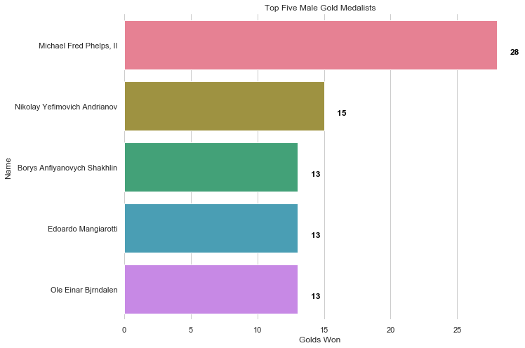

```python
# Set seaborn style and figure size
sns.set(style = 'whitegrid')
plt.figure(figsize = (10, 8))

# Give chart title, labels, and limits
plt.title('Top Five Male Gold Medalists')
plt.xlabel('Number of Gold Medals Won')
plt.ylabel('Name of Athlete')

# Plot barplot
sns.barplot(x = male_gold['Golds Won'], y = male_gold['Name'],
           palette = 'husl')

# Text for number of medals (at the end of each bar)
for i, v in enumerate(male_gold['Golds Won']):
    plt.text(v + 1, i + .15, str(v), color = 'black', fontweight = 'bold', fontsize = 12)

# Removing axes spines
sns.despine(left = True, bottom = True)

plt.savefig('Visualization/Top Male Gold Medalists.png')
```

## Average Height, Weight, & Age of Female Athletes by Sport

```python
# Create a Dataframe that features data from 1960 to 2016

mod_olympic = olympic_metadata[(olympic_metadata['Year'] >= 1960)]
```

```python
# Do groupby on 'Year' and 'ID' to grab first athlete info for every year

mod_olympic = mod_olympic.groupby(['Year', 'ID']).first().reset_index()
mod_olympic.head()
```

|  | Year | ID | Name | Sex | Age | Height | Weight | Team | NOC | Games | Season | City | Sport | Event | Medal | Country | Notes |
| --- | --- | --- | --- | --- | --- | --- | --- | --- | --- | --- | --- | --- | --- | --- | --- | --- | --- |
| 0 | 1960 | 24 | Nils Egil Aaness | M | 24.0 | NaN | NaN | Norway | NOR | 1960 Winter | Winter | Squaw Valley | Speed Skating | Speed Skating Men's 500 metres | NaN | Norway | NaN |
| 1 | 1960 | 40 | Roald Edgar Aas | M | 31.0 | NaN | NaN | Norway | NOR | 1960 Winter | Winter | Squaw Valley | Speed Skating | Speed Skating Men's 1,500 metres | Gold | Norway | NaN |
| 2 | 1960 | 46 | Hans Aasns | M | 57.0 | 194.0 | 93.0 | Norway | NOR | 1960 Summer | Summer | Roma | Shooting | Shooting Men's Trap | NaN | Norway | NaN |
| 3 | 1960 | 59 | Ivan Nikolov Abadzhiev | M | 28.0 | 164.0 | 71.0 | Bulgaria | BUL | 1960 Summer | Summer | Roma | Weightlifting | Weightlifting Men's Middleweight | NaN | Bulgaria | NaN |
| 4 | 1960 | 60 | Mikhail Abadzhiev | M | 24.0 | 172.0 | 75.0 | Bulgaria | BUL | 1960 Summer | Summer | Roma | Weightlifting | Weightlifting Men's Middleweight | NaN | Bulgaria | NaN |

```python
# Get athlete average athlete height, weight, and age by discipline and gender

athlete_info = mod_olympic.groupby(['Sport', 'Sex'])['Height', 'Weight', 'Age'].mean().dropna().reset_index()
athlete_info = athlete_info.round({'Height': 2, 'Weight': 2})
athlete_info['Age'] = athlete_info['Age'].astype(int)
athlete_info.head()
```

|  | Sport | Sex | Height | Weight | Age |
| --- | --- | --- | --- | --- | --- |
| 0 | Alpine Skiing | F | 167.13 | 62.47 | 22 |
| 1 | Alpine Skiing | M | 178.00 | 78.70 | 23 |
| 2 | Archery | F | 167.04 | 61.76 | 26 |
| 3 | Archery | M | 178.24 | 76.62 | 27 |
| 4 | Athletics | F | 169.52 | 60.54 | 25 |

```python
# Retrieve all female info

female_info = athlete_info.loc[athlete_info['Sex'] == 'F'].reset_index(drop = True)
female_info.head()
```

|  | Sport | Sex | Height | Weight | Age |
| --- | --- | --- | --- | --- | --- |
| 0 | Alpine Skiing | F | 167.13 | 62.47 | 22 |
| 1 | Archery | F | 167.04 | 61.76 | 26 |
| 2 | Athletics | F | 169.52 | 60.54 | 25 |
| 3 | Badminton | F | 168.33 | 61.48 | 24 |
| 4 | Basketball | F | 182.45 | 73.69 | 25 |

```python
# Create output to static HTML file
output_file('Visualization/Avg. Female Athlete Info.html')

# Create column data source
female_src = ColumnDataSource(female_info)

# Create cmapper for color
f_cmapper = factor_cmap('Sport', palette = Plasma256, factors = female_info['Sport'])

# Create Scatterplot
p = figure()
p.scatter(x = 'Weight', y = 'Height', source = female_src, size = 'Age',
         alpha = 0.7, fill_color = f_cmapper, color = f_cmapper)

# Add title and axis labels
p.title.text = 'Average Height & Weight of Female Athletes by Sport'
p.xaxis.axis_label = 'Weight (kg)'
p.yaxis.axis_label = 'Height (cm)'

# Add hover tool info
hover = HoverTool()
hover.tooltips = [
    ('Sport', '@Sport'),
    ('Avg. Age', '@Age'),
    ('Avg. Height', '@Height'),
    ('Avg. Weight', '@Weight')
]

p.add_tools(hover)

show(p)
```

[interactive chart not shown]

## Average Height, Weight, & Age of Male Athletes by Sport

```python
# Retrieve all male info

male_info = athlete_info.loc[athlete_info['Sex'] == 'M'].reset_index(drop = True)
male_info.head()
```

|  | Sport | Sex | Height | Weight | Age |
| --- | --- | --- | --- | --- | --- |
| 0 | Alpine Skiing | M | 178.00 | 78.70 | 23 |
| 1 | Archery | M | 178.24 | 76.62 | 27 |
| 2 | Athletics | M | 180.49 | 74.84 | 25 |
| 3 | Badminton | M | 179.41 | 74.07 | 26 |
| 4 | Baseball | M | 182.60 | 85.71 | 26 |

```python
# Create output to static HTML file
output_file('Visualization/Avg. Male Athlete Info.html')

# Create column data source
male_src = ColumnDataSource(male_info)

# Create cmapper for color
m_cmapper = factor_cmap('Sport', palette = Cividis256, factors = male_info['Sport'])

# Create Scatterplot
p = figure()
p.scatter(x = 'Weight', y = 'Height', source = male_src, size = 'Age',
          alpha = 0.7, fill_color = m_cmapper, color = m_cmapper)

# Add title and axis labels
p.title.text = 'Average Height & Weight of Male Athletes by Sport'
p.xaxis.axis_label = 'Weight (kg)'
p.yaxis.axis_label = 'Height (cm)'

# Add hover tool info
hover = HoverTool()
hover.tooltips = [
    ('Sport', '@Sport'),
    ('Avg. Age', '@Age'),
    ('Avg. Height', '@Height'),
    ('Avg. Weight', '@Weight')
]

p.add_tools(hover)

show(p)
```

[interactive chart not shown]

## Conclusion

### Findings:

1. Overall, athlete participation in the Olympics have been on a steady raise with exceptions of a few years where there was a noticeable low participation turnout.

- 1904 Olympics (St. Louis, USA)
  - Russo-Japanese War
  - Travel difficulties for athletes from outside of N. America
- 1932 Olympics (Los Angeles, USA)
  - The Great Depression
- 1956 Olympics (Stockholm, SWE and Melbourne, AUS)
  - Second Arab-Isreali War
  - Netherlands, Spain, Switzerland, and Cambodia withdrew from the Games (due to USSR & Hungarian Revolution conflict)
  - China withdrew from the Games because the IOC allowed Taiwan to participate in the Games
- 1980 Olympics (Moscow, RUS)
  - Soviet Afghan War
    - 66 countries boycotted the Games
- 1936 Olympics (Berlin, GER) * -- high participation turnout
  - Games held during WWII and Nazi Germany reign
    - Hitler wanted to outdo the 1932 Olympics
  - Black athletes wanted to participate in the Olympics-- viewed that black victories would undermine Nazi views
    - Jesse Owens won 4 gold medals during the Berlin Games
      - Competed in adidas track shoes
      - First sponsorship for an African American athlete

2. Top medaling countries in both Summer and Winter Games are USA, Russia, Germany, UK, and France.

4. Most female athletes average around 57 kg to 67 kg (126 lbs to 148 lbs) in weight, 164 cm to 170 cm (5'4'' to 5'6'') in height and are in their mid 20s.

5. Most male athletes average around 72 kg to 82 kg (159 lbs to 181 lbs) in weight, 176 cm to 182 cm (5'8'' to 5'10'') in height and are in their early to mid 20s.

- Gymnasts are the smaller athletes (139 lbs and 5'5'')
- Basketball players are the bigger athletes (203 lbs and 6'4'')

### Problems Faced:

- Missing data in age, weight, and height columns
- Some of the countries had more than one country code
- Athletes who participated in the 1956 Olympics were either listed under Melbourne or Stockholm
- Dataset included athletes who participated in the 1906 Olympics (IOC does not recognize the 1906 Olympics)

### Next Steps:

To expand more on this project, I would do some research into finding stats on athletes in a particular sport (like basketball), merge my findings with the existing data, and then analyze the evolution of athletes in that sport.